# Lecture 8: Bill of Rights Part 1

USGOVT101: U.S. Constitution and Politics

The Politics Tutor: US Politics Explained

2026-09-20

## Today

- “Congress shall make no law…” — federal only
- Religion clauses: establishment and free exercise
- The home as a special zone of protection
- What the text does *not* create: a general right to privacy
- A basis for asking: What is missing?

# Why This Matters

## Why This Matters

By the end of today you will explain why “Congress shall make no law” originally bound only the federal government, how the religion clauses protected both free exercise and state establishments, and why the Bill of Rights treats the home as a special zone of protection without creating a general right to privacy — giving you a basis for asking: What is missing?

## Bridge

- Unfinished contract and formal amendments (Lecture 7)
- Today: the first great list of limits on *federal* power
- As understood at the Founding — and what changed in the 1940s

# Congress Shall Make No Law

## Congress shall make no law…

[figure not shown]

## Federal only

The Bill of Rights originally limited the *federal* government — not the states

## As understood at the time

- Demand was for restraint on the new national government
- Most states already had their own bills or declarations of rights
- Barron v. Baltimore (1833): Bill of Rights does not apply to the states
- That understanding held until the 1940s (incorporation through the 14th)

# Religion Clauses

## First Amendment — religion

Congress shall make no law respecting an establishment of religion, or prohibiting the free exercise thereof…

## No national establishment

- No official national church
- No automatic membership by birth
- No national tax support for churches
- No federal payment of clergy salaries

## It protected state establishments

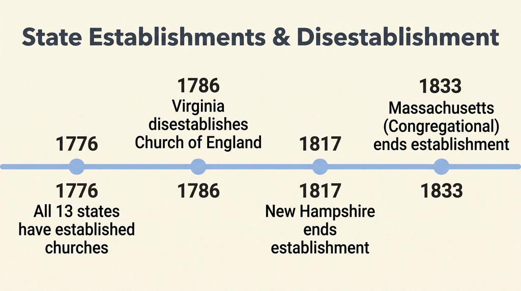

Timeline of state church establishments and disestablishment

## Free exercise

Practice according to conscience — or not

## Worked with, not against

No establishment and free exercise reinforce each other

## Not in the text

“Separation of church and state” does not appear in the Constitution

# Second Amendment

## Second Amendment

A well regulated Militia, being necessary to the security of a free State, the right of the people to keep and bear Arms, shall not be infringed.

## As written

- Militia clause explains one reason the right is desirable
- The right is held by *the people*
- Disagreement about the explanation does not erase the right of the people

# The Home

## Third Amendment

No Soldier shall, in time of peace be quartered in any house, without the consent of the Owner, nor in time of war, but in a manner to be prescribed by law.

## The home is your castle

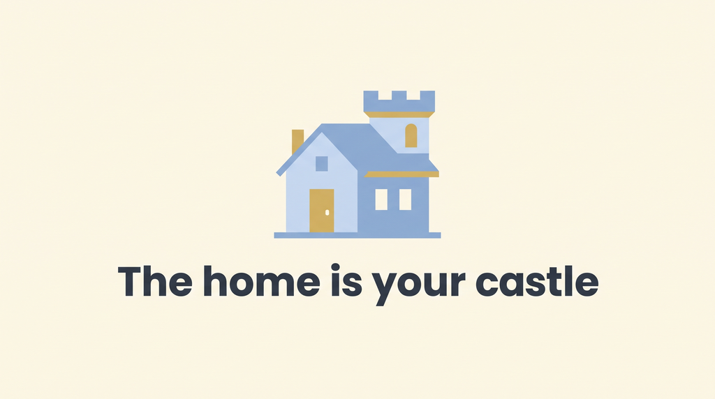

Illustration of the home as castle

## Fourth Amendment

The right of the people to be secure in their persons, houses, papers, and effects, against unreasonable searches and seizures, shall not be violated…

## Secure in their…

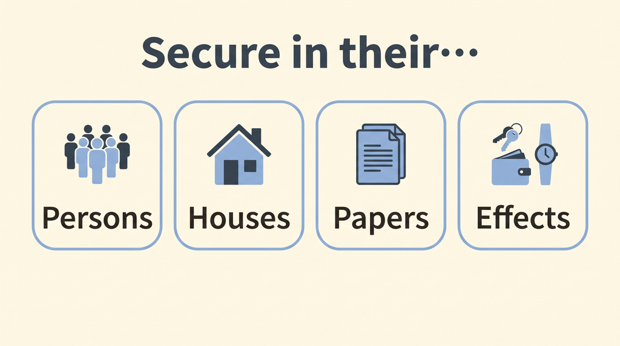

Four sanctums of the Fourth Amendment: persons, houses, papers, effects

## Warrant requirements

- Probable cause
- Oath or affirmation
- Particular description of place
- Particular description of persons or things

# Property and Due Process

## Fifth Amendment — property focus

…nor be deprived of life, liberty, or property, without due process of law; nor shall private property be taken for public use, without just compensation.

## Due process protects

- Life
- Liberty
- Property

## Takings Clause

Public use + just compensation

## Later

Criminal-suspect protections in the Fifth, Sixth, and Eighth return in Court Cases lectures

# People and States

## Ninth Amendment

The enumeration in the Constitution, of certain rights, shall not be construed to deny or disparage others retained by the people.

## Tenth Amendment

The powers not delegated to the United States by the Constitution, nor prohibited by it to the States, are reserved to the States respectively, or to the people.

## Rights and powers

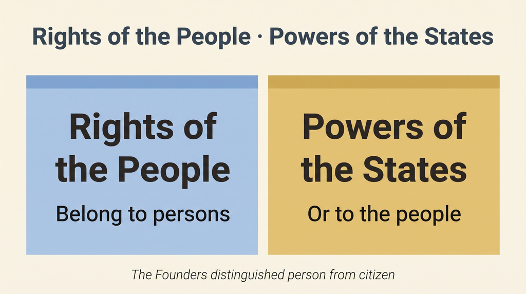

Diagram distinguishing rights of the people from powers of the states

## Person and citizen

The Founders knew the difference between a person and a citizen

# What Is Missing?

## No general right to privacy

Massive protections for the home — no free-floating right to privacy in the text

## Discussion

Should we pass a right-to-privacy amendment?

- What should it say?
- How and where should it apply?

## Incorporation (preview)

Most of these limits later reach the states through the 14th Amendment — we return there in Court Cases

# Next

## Next lecture: Better Angels of Our Nature

Short lecture, then discussion of why we limit government based on material so far.

## Watch

Channel: [TikTok @us_politics_explained](https://www.tiktok.com/@us_politics_explained)

Clips that pair with this lecture:

- [The Bill of Rights Explained](https://www.tiktok.com/@us_politics_explained/video/7552578637275434254)

## Authorship and License

- Author: The Politics Tutor
- Channel: [TikTok @us_politics_explained](https://www.tiktok.com/@us_politics_explained)
- License: [CC BY-NC-SA 4.0](http://creativecommons.org/licenses/by-nc-sa/4.0/)